| title: “CARPS Reproducibility Report” |
| --- |
| output: |
| html_document: |
| toc: true |
| toc_float: true |

# Report Details

```r
articleID <- "EXT_208-5-2015" # insert the article ID code here e.g., "10-3-2015_PS"
reportType <- 'pilot' # specify whether this is the 'pilot' report or 'final' report
pilotNames <- "Vivian Zhang" # insert the pilot's name here e.g., "Tom Hardwicke".  If there are multiple cpilots enter both names in a character string e.g., "Tom Hardwicke, Bob Dylan"
copilotNames <- NA # # insert the co-pilot's name here e.g., "Michael Frank". If there are multiple co-pilots enter both names in a character string e.g., "Tom Hardwicke, Bob Dylan"
pilotTTC <- NA # insert the pilot's estimated time to complete (in minutes, fine to approximate) e.g., 120
copilotTTC <- NA # insert the co-pilot's estimated time to complete (in minutes, fine to approximate) e.g., 120
pilotStartDate <- 10/19/2018 # insert the pilot's start date in US format e.g., as.Date("01/25/18", format = "%m/%d/%y")
copilotStartDate <- NA # insert the co-pilot's start date in US format e.g., as.Date("01/25/18", format = "%m/%d/%y")
completionDate <- NA # copilot insert the date of final report completion (after any necessary rounds of author assistance) in US format e.g., as.Date("01/25/18", format = "%m/%d/%y")
```

#### Methods summary:

The study tested 64 American participants and 67 Korean participants who are undergraduate students. The researchers selected 45 pairs of Korean politicians from Assembly election, and 45 pairs of American politicians in gubernatorial and senatorial elections of the same genders. Images of these political condidates’ faces were shown to participants on a computer screen, and participants indicated which of each pair they perceived to be more competent; then, the same pairs of political candidates were shown again and participants indicated which of each pair they would vote for in a hypothetical election.In hypothetical elections, both Koreans and Americans voted based on perceived competence inferred from facial appearance. However, according to real election results, perceived competence was a far better predictor of the outcomes of real elections held in the US than of those in Korea.

#### Target outcomes paragraph:

For this article you should focus on the findings reported in the results section pertaining to “Prediction of outcomes in actual elections in Korea and the United States”.

Specifically, you should attempt to reproduce all descriptive and inferential analyses reported in the text below and associated tables/figures:

Prediction of outcomes in actual elections in Korea and the United States. Next, we investigated whether perceived competence, for which there was consensus within and between cultures, could predict election results in the United States and Korea. The percentage of successfully elected candidates rated as more competent was calculated separately for each participant for each election location. These scores were submitted to a 2 (participant’s culture: Koreans vs. Americans) × 2 (election location: Korea vs. United States) mixed analysis of variance (ANOVA) with election location as a within-subjects factor. There was a strong main effect of election location such that perceived competence was a better predictor of the outcome of American elections than of Korean elections, F(1, 129) = 115.98, p < .001, ηp2 = .47. Note that the significance of this election-location effect was driven by actual voters in real elections, not by participants in the present research. More specifically, this finding suggests that American voters in real elections voted for the competent-looking candidates, whereas this tendency was significantly weaker among Korean voters in real elections. The strength of this effect is illustrated by the means (Korean elections: 51.38%; American elections: 61.13%) and confidence intervals associated with the effect, difference = 9.75 percentage points, 95% CI = [7.94, 11.57]. There was no effect of participants’ culture, F < 1. There was, however, a Participant’s Culture × Election Location interaction, F(1, 129) = 6.17, p = .014, ηp2 = .05. Although the interaction was statistically significant, the 95% CIs did not clearly separate the interaction means. We discuss this interaction in the next section.

Korean participants. Next, we examined the consistency of the main effect within each culture. First, among Koreans, candidates who were perceived as more competent won in 61.92% of American elections but in only 49.98% of Korean elections, t(66) = 9.08, p < .001 (Fig. 1). The effect size for the difference (11.94 percentage points) was large, d = 1.11, and even the lower limit of the 95% CI was larger than zero, 95% CI = [9.32, 14.57]. Moreover, Koreans’ competence judgments predicted the U.S. election results at a level better than chance (i.e., 50%), difference = 11.92 percentage points, d = 2.73, 95% CI = [9.77, 14.07]. However, Koreans’ competence judgments predicted Korean election results at chance levels, difference = −0.02 percentage points, 95% CI = [−2.05, 2.01]. We also note that the difference from chance for Koreans predicting American election results was significant, t(66) = 11.08, p < .00. This was not the case for Koreans predicting Korean election results, t(66) = 0.02, n.s. American participants. Conceptually, the same pattern was observed for Americans (Fig. 1). For Americans, more winning candidates were perceived as more competent than their competitors in American elections (60.31%) than in Korean elections (52.85%). Again, the effect size for the difference (7.46 percentage points) was large, d = 0.70, and the lower limit of the 95% CI was above zero,95% CI = [5.01, 9.92]. The difference was statistically significant, t(63) = 6.09, p < .001. In addition, Americans’ competence judgments predicted American election results at a level better than chance, difference = 10.31 percentage points, t(63) = 11.53, 95% CI = [8.52, 12.10], p < .001, d = 2.90. However, for Korean elections, the difference from chance was relatively small (2.85 percentage points), and the lower limit of the 95% CI was close to zero, 95% CI = [0.49, 5.21], although the difference was significant, t(63) = 2.41, p = .019, d = 0.61.

# Step 1: Load packages and prepare report object

```r
# load packages
library(tidyverse) # for data munging
library(knitr) # for kable table formating
library(haven) # import and export 'SPSS', 'Stata' and 'SAS' Files
library(readxl) # import excel files
library(CARPSreports) # custom report functions
library(ez)
library(DescTools)
library(readxl)
library(lsr)
```

```r
# Pilot/copilot: Do not make changes to this code chunk!
# Prepare report object. This will be updated automatically by the reproCheck function each time values are compared
reportObject <- data.frame(dummyRow = TRUE, reportedValue = NA, obtainedValue = NA, valueType = NA, percentageError = NA, comparisonOutcome = NA, eyeballCheck = NA)
```

# Step 2: Load data

```r
election_data_JNA <- read_excel("data/election_data_JNA.xlsx")
KOR_consensus <- read_excel("data/KOR_consensus.xlsx")
US_consensus <- read_excel("data/US_consensus.xlsx")
```

# Step 3: Tidy data

```r
d.tidy <- election_data_JNA %>%
  select("ID", "culture","Pro_KOR", "Pro_US")

# rename variables
d.tidy <- d.tidy %>%
  rename(subject_id = "ID",
         participants = "culture",
         KE_accuracy = "Pro_KOR",
         UE_accuracy = "Pro_US")
d.long <- d.tidy %>%
  gather(country, accuracy, KE_accuracy, UE_accuracy)
d.long <- d.long %>%
  mutate(location = ifelse(country == "UE_accuracy", 1, 2),
         group = ifelse(participants ==1 & location ==1, 1,
                        ifelse(participants ==1 & location ==2, 2,
                               ifelse(participants ==2 & location ==1, 3,
                                      ifelse(participants ==2 & location ==2, 4,5
                                             )))))

d.ready <- d.long %>%
  select("subject_id","group", "participants", "location", "accuracy")

  d.ready$participants[d.ready$participants == 1] = "US"
  d.ready$participants[d.ready$participants == 2] <- "Korea"
  d.ready$location[d.ready$location == 1] <- "US"
  d.ready$location[d.ready$location == 2] <- "Korea"

d.ready$subject_id = factor(d.ready$subject_id)
d.ready$group = factor(d.ready$group)
d.ready$location = factor(d.ready$location)
d.ready$participants = factor(d.ready$participants)
d.ready$accuracy = as.numeric(d.ready$accuracy)
```

# Step 4: Descriptive and Inferential Statistics

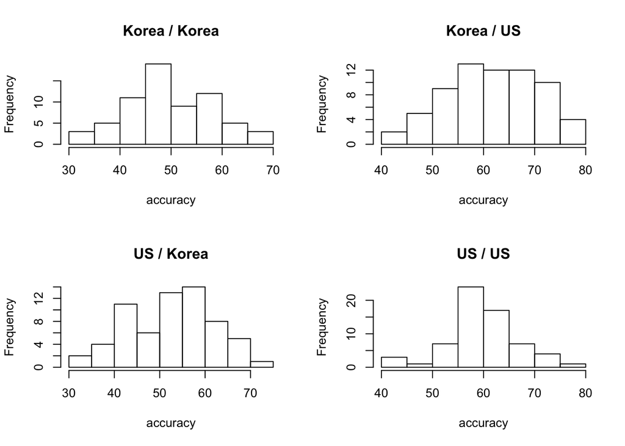

```r
# Check assumptions of ANOVA
# Assumption 1: no ouliers
par(mfrow = c(2,2))
for (i in levels(d.ready$participants)) {
  for (j in levels(d.ready$location)){
    hist(d.ready[d.ready$participants == i & d.ready$location == j, ]$accuracy,
         xlab = "accuracy",
         main = paste0(i, " / ", j))
  }
}
```

```r
par(mfrow=c(1,1))

# Assumption 2: equal variance assumptions
# Bartelett Test
bartlett.test(accuracy ~ group, data = d.ready)
```

```
##
##  Bartlett test of homogeneity of variances
##
## data:  accuracy by group
## Bartlett's K-squared = 5.0421, df = 3, p-value = 0.1687
```

```r
# Results: 1. there is no outliers.
#          2. K^2(3) = 5.04, p = 0.169 >0.05. Thus, there is no significant               variance within group across the 4 groups.
```

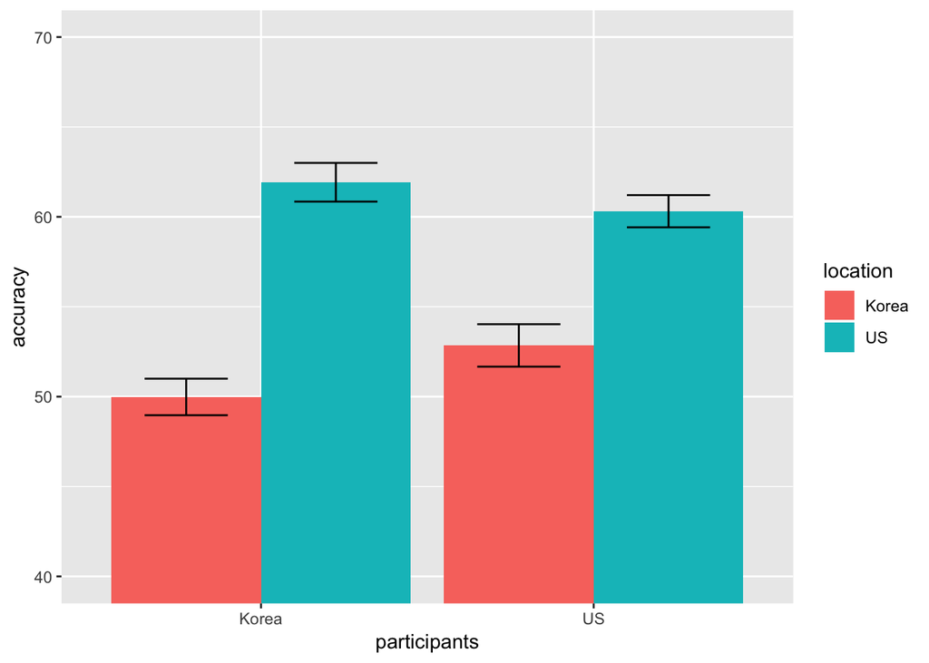

```r
d.mean = aggregate(accuracy~ participants*location, data = d.ready, FUN = mean)
d.sd = aggregate(accuracy~ participants*location, data = d.ready, FUN = sd)
d.n = aggregate(accuracy~ participants*location, data = d.ready, FUN = length)


names(d.sd)[3] = "sd"
names(d.n)[3] = "n"
dSummary = cbind(d.mean, d.sd$sd, d.n$n)
names(dSummary)[4] = "sd"
names(dSummary)[5] = "n"
dSummary$se = dSummary$sd/ dSummary$n^0.5

# Visualization (Fig 1 in paper)
ggplot(data = dSummary, aes(x = participants, y = accuracy, fill = location))+
  geom_bar(position = position_dodge(),stat = "identity") +
  geom_errorbar(
    aes(ymax = accuracy + se,
        ymin = accuracy - se),
    width = 0.5,
    position = position_dodge(.9))+
  coord_cartesian(ylim = c(40,70))
```

```r
# ANOVA
d.aov = aov(accuracy ~ as.factor(participants)*as.factor(location) +
Error(subject_id/location), data = d.ready)
summary(d.aov)
```

```
##
## Error: subject_id
##                          Df Sum Sq Mean Sq F value Pr(>F)
## as.factor(participants)   1     26   25.68   0.283  0.595
## Residuals               129  11689   90.61
##
## Error: subject_id:location
##                                              Df Sum Sq Mean Sq F value
## as.factor(location)                           1   6232    6232 117.266
## as.factor(participants):as.factor(location)   1    328     328   6.167
## Residuals                                   129   6855      53
##                                             Pr(>F)
## as.factor(location)                         <2e-16 ***
## as.factor(participants):as.factor(location) 0.0143 *
## Residuals
## ---
## Signif. codes:  0 '***' 0.001 '**' 0.01 '*' 0.05 '.' 0.1 ' ' 1
```

```r
EtaSq(d.aov, type = 1, anova = TRUE)
```

```
##                                                  eta.sq eta.sq.part
## as.factor(participants)                     0.001021856 0.002192022
## as.factor(location)                         0.247985923 0.476175602
## as.factor(participants):as.factor(location) 0.013042512 0.045628190
##                                              eta.sq.gen         SS df
## as.factor(participants)                     0.001382809   25.67865  1
## as.factor(location)                         0.251523441 6231.74065  1
## as.factor(participants):as.factor(location) 0.017367040  327.75067  1
##                                                     MS       SSE dfE
## as.factor(participants)                       25.67865 11688.919 129
## as.factor(location)                         6231.74065  6855.323 129
## as.factor(participants):as.factor(location)  327.75067  6855.323 129
##                                                      F            p
## as.factor(participants)                       0.283392 5.954023e-01
## as.factor(location)                         117.265734 7.777221e-20
## as.factor(participants):as.factor(location)   6.167446 1.429505e-02
```

```r
## Prediction of outcomes in actual elections in Korea and the United States
# Maineffect of Election Location
reportObject <- reproCheck(reportedValue = '1', obtainedValue = 1, valueType = 'df')
```

```
## [1] "MATCH for df. The reported value (1) and the obtained value (1) differed by 0%. Note that the obtained value was rounded to 0 decimal places to match the reported value."
```

```r
reportObject <- reproCheck(reportedValue = '129', obtainedValue = 129, valueType = 'df')
```

```
## [1] "MATCH for df. The reported value (129) and the obtained value (129) differed by 0%. Note that the obtained value was rounded to 0 decimal places to match the reported value."
```

```r
reportObject <- reproCheck(reportedValue = '115.98', obtainedValue = 117.266, valueType = 'F')
```

```
## [1] "MINOR_ERROR for F. The reported value (115.98) and the obtained value (117.27) differed by 1.11%. Note that the obtained value was rounded to 2 decimal places to match the reported value."
```

```r
# reportObject <- reproCheck(reportedValue = '< 0.001', obtainedValue = 7.78e-20, valueType = 'p')
# p = 7.78e-20 < 0.001 MATCH
reportObject <- reproCheck(reportedValue = '0.47', obtainedValue = 0.48, valueType = 'pes')
```

```
## [1] "MINOR_ERROR for pes. The reported value (0.47) and the obtained value (0.48) differed by 2.13%. Note that the obtained value was rounded to 2 decimal places to match the reported value."
```

```r
# Participant & Location Interaction
reportObject <- reproCheck(reportedValue = '1', obtainedValue = 1, valueType = 'df')
```

```
## [1] "MATCH for df. The reported value (1) and the obtained value (1) differed by 0%. Note that the obtained value was rounded to 0 decimal places to match the reported value."
```

```r
reportObject <- reproCheck(reportedValue = '129', obtainedValue = 129, valueType = 'df')
```

```
## [1] "MATCH for df. The reported value (129) and the obtained value (129) differed by 0%. Note that the obtained value was rounded to 0 decimal places to match the reported value."
```

```r
reportObject <- reproCheck(reportedValue = '6.17', obtainedValue = 6.17, valueType = 'F')
```

```
## [1] "MATCH for F. The reported value (6.17) and the obtained value (6.17) differed by 0%. Note that the obtained value was rounded to 2 decimal places to match the reported value."
```

```r
reportObject <- reproCheck(reportedValue = '0.014', obtainedValue = 0.0143, valueType = 'p')
```

```
## [1] "MATCH for p. The reported value (0.014) and the obtained value (0.014) differed by 0%. Note that the obtained value was rounded to 3 decimal places to match the reported value."
```

```r
reportObject <- reproCheck(reportedValue = '0.05', obtainedValue = 0.05, valueType = 'pes')
```

```
## [1] "MATCH for pes. The reported value (0.05) and the obtained value (0.05) differed by 0%. Note that the obtained value was rounded to 2 decimal places to match the reported value."
```

```r
## Strength of Election Location Main Effect
t.test(accuracy ~ location, data = d.ready, conf.level = .95)
```

```
##
##  Welch Two Sample t-test
##
## data:  accuracy by location
## t = -9.2595, df = 257.06, p-value < 2.2e-16
## alternative hypothesis: true difference in means is not equal to 0
## 95 percent confidence interval:
##  -11.82844  -7.67962
## sample estimates:
## mean in group Korea    mean in group US
##            51.38253            61.13656
```

```r
# Difference
difference = 61.13656 - 51.38253
difference
```

```
## [1] 9.75403
```

```r
## Difference between Korean and the US, and Confidence Interval
# Difference between means
reportObject <- reproCheck(reportedValue = '51.38', obtainedValue = 51.38, valueType = 'mean')
```

```
## [1] "MATCH for mean. The reported value (51.38) and the obtained value (51.38) differed by 0%. Note that the obtained value was rounded to 2 decimal places to match the reported value."
```

```r
reportObject <- reproCheck(reportedValue = '61.13', obtainedValue = 61.14, valueType = 'mean')
```

```
## [1] "MINOR_ERROR for mean. The reported value (61.13) and the obtained value (61.14) differed by 0.02%. Note that the obtained value was rounded to 2 decimal places to match the reported value."
```

```r
reportObject <- reproCheck(reportedValue = '9.75', obtainedValue = 9.75,
valueType = 'other')
```

```
## [1] "MATCH for other. The reported value (9.75) and the obtained value (9.75) differed by 0%. Note that the obtained value was rounded to 2 decimal places to match the reported value."
```

```r
# Confidence Interval
reportObject <- reproCheck(reportedValue = '7.94', obtainedValue = 7.68, valueType = 'ci')
```

```
## [1] "MINOR_ERROR for ci. The reported value (7.94) and the obtained value (7.68) differed by 3.27%. Note that the obtained value was rounded to 2 decimal places to match the reported value."
```

```r
reportObject <- reproCheck(reportedValue = '11.57', obtainedValue = 11.83, valueType = 'ci')
```

```
## [1] "MINOR_ERROR for ci. The reported value (11.57) and the obtained value (11.83) differed by 2.25%. Note that the obtained value was rounded to 2 decimal places to match the reported value."
```

```r
## Details of Participants and Location Interaction
# Korean Participants
d.K <- d.ready %>%
filter(participants == "Korea") %>%
select(-c ("group", "participants"))
d.K <- d.K %>%
spread(location, accuracy)
t.test(d.K$Korea, d.K$US, data = d.K, paired = TRUE)
```

```
##
##  Paired t-test
##
## data:  d.K$Korea and d.K$US
## t = -9.0823, df = 66, p-value = 3.106e-13
## alternative hypothesis: true difference in means is not equal to 0
## 95 percent confidence interval:
##  -14.56513  -9.31547
## sample estimates:
## mean of the differences
##                -11.9403
```

```r
mean(d.K$Korea)
```

```
## [1] 49.98342
```

```r
mean(d.K$US)
```

```
## [1] 61.92371
```

```r
cohensD(x = d.K$Korea, y = d.K$US)
```

```
## [1] 1.393496
```

```r
# cohen.d (d = d.K$Korea, f = d.K$US)
```

```r
# Difference between means
reportObject <- reproCheck(reportedValue = '61.92', obtainedValue = 61.92, valueType = 'mean')
```

```
## [1] "MATCH for mean. The reported value (61.92) and the obtained value (61.92) differed by 0%. Note that the obtained value was rounded to 2 decimal places to match the reported value."
```

```r
reportObject <- reproCheck(reportedValue = '49.98', obtainedValue = 49.98, valueType = 'mean')
```

```
## [1] "MATCH for mean. The reported value (49.98) and the obtained value (49.98) differed by 0%. Note that the obtained value was rounded to 2 decimal places to match the reported value."
```

```r
reportObject <- reproCheck(reportedValue = '11.94', obtainedValue = 11.94,
valueType = 'mean')
```

```
## [1] "MATCH for mean. The reported value (11.94) and the obtained value (11.94) differed by 0%. Note that the obtained value was rounded to 2 decimal places to match the reported value."
```

```r
# T-test results
reportObject <- reproCheck(reportedValue = '66', obtainedValue = 66, valueType = 'df')
```

```
## [1] "MATCH for df. The reported value (66) and the obtained value (66) differed by 0%. Note that the obtained value was rounded to 0 decimal places to match the reported value."
```

```r
reportObject <- reproCheck(reportedValue = '9.08', obtainedValue = 9.08, valueType = 't')
```

```
## [1] "MATCH for t. The reported value (9.08) and the obtained value (9.08) differed by 0%. Note that the obtained value was rounded to 2 decimal places to match the reported value."
```

```r
# reportObject <- reproCheck(reportedValue = '< 0.001', obtainedValue = 3.106e-13, valueType = 'p')
# p = 3.106e-13 < 0.001 MATCH
# Effect size
reportObject <- reproCheck(reportedValue = '1.11', obtainedValue = 1.39, valueType = 'd')
```

```
## [1] "MAJOR_ERROR for d. The reported value (1.11) and the obtained value (1.39) differed by 25.23%. Note that the obtained value was rounded to 2 decimal places to match the reported value."
```

```r
# Confidence Interval
reportObject <- reproCheck(reportedValue = '9.32', obtainedValue = 9.32, valueType = 'ci')
```

```
## [1] "MATCH for ci. The reported value (9.32) and the obtained value (9.32) differed by 0%. Note that the obtained value was rounded to 2 decimal places to match the reported value."
```

```r
reportObject <- reproCheck(reportedValue = '14.57', obtainedValue = 14.57, valueType = 'ci')
```

```
## [1] "MATCH for ci. The reported value (14.57) and the obtained value (14.57) differed by 0%. Note that the obtained value was rounded to 2 decimal places to match the reported value."
```

```r
# Korean's prediction of US and Korea election compared to chance
diff_K <- d.K$Korea - 50
t.test(diff_K, mu = 0)
```

```
##
##  One Sample t-test
##
## data:  diff_K
## t = -0.016319, df = 66, p-value = 0.987
## alternative hypothesis: true mean is not equal to 0
## 95 percent confidence interval:
##  -2.045540  2.012373
## sample estimates:
##   mean of x
## -0.01658375
```

```r
cohensD(x = diff_K, mu = 0)
```

```
## [1] 0.001993682
```

```r
diff_U <- d.K$US - 50
t.test(diff_U, mu = 0)
```

```
##
##  One Sample t-test
##
## data:  diff_U
## t = 11.076, df = 66, p-value < 2.2e-16
## alternative hypothesis: true mean is not equal to 0
## 95 percent confidence interval:
##   9.774319 14.073111
## sample estimates:
## mean of x
##  11.92371
```

```r
cohensD(x = diff_U, mu = 0)
```

```
## [1] 1.353135
```

```r
## Koreans predict US election
# T-test results
reportObject <- reproCheck(reportedValue = '66', obtainedValue = 66, valueType = 'df')
```

```
## [1] "MATCH for df. The reported value (66) and the obtained value (66) differed by 0%. Note that the obtained value was rounded to 0 decimal places to match the reported value."
```

```r
reportObject <- reproCheck(reportedValue = '11.08', obtainedValue = 11.08, valueType = 't')
```

```
## [1] "MATCH for t. The reported value (11.08) and the obtained value (11.08) differed by 0%. Note that the obtained value was rounded to 2 decimal places to match the reported value."
```

```r
# reportObject <- reproCheck(reportedValue = '< 0.001', obtainedValue < 2.2 e-16, valueType = 'p')
# p < 2.2 e-16 < 0.001 MATCH
# Effect size
reportObject <- reproCheck(reportedValue = '2.73', obtainedValue = 1.35, valueType = 'd')
```

```
## [1] "MAJOR_ERROR for d. The reported value (2.73) and the obtained value (1.35) differed by 50.55%. Note that the obtained value was rounded to 2 decimal places to match the reported value."
```

```r
# Difference and Confidence Interval
reportObject <- reproCheck(reportedValue = '11.92', obtainedValue = 11.92, valueType = 'mean')
```

```
## [1] "MATCH for mean. The reported value (11.92) and the obtained value (11.92) differed by 0%. Note that the obtained value was rounded to 2 decimal places to match the reported value."
```

```r
reportObject <- reproCheck(reportedValue = '9.77', obtainedValue = 9.77, valueType = 'ci')
```

```
## [1] "MATCH for ci. The reported value (9.77) and the obtained value (9.77) differed by 0%. Note that the obtained value was rounded to 2 decimal places to match the reported value."
```

```r
reportObject <- reproCheck(reportedValue = '14.07', obtainedValue = 14.07, valueType = 'ci')
```

```
## [1] "MATCH for ci. The reported value (14.07) and the obtained value (14.07) differed by 0%. Note that the obtained value was rounded to 2 decimal places to match the reported value."
```